# PHYS 210 Day 06

### 2026 - 09 - 28

Agenda:

1. Announcements: **Test 1 window is OPEN through Fri Oct 2** · no class Wed Sep 30 (Truth and Reconciliation Day) · Homework 06 + Preclass 07 due **Mon Oct 5, 9 am**
2. Reading 06 recap, Q&A and polling questions: masks, `np.where`, views, `meshgrid`
3. Group Worksheet 06

## Test 1 is this week

- Window **Mon Sep 28 – Fri Oct 2**, one 50-minute sitting at ORCA (ICICS, 201-2366 Main Mall), covers Days 01–04
- At ORCA: no internet, no AI tools; reference notes are inside the test; same question styles as Practice Test 1
- Not on Test 1: masks, views and `meshgrid` are Test 2 material (Days 05–08, window opens Tue Oct 13)

## Reading recap: more arrays

- Array filtering (coming up in the Q&A):
  - `a[[1, 3, 5]]` gives an array of the 2nd, 4th and 6th elements of `a` (fancy indexing)
  - `np.where(a > 0)` gives the **indices** where the mask `a > 0` (Worksheet 05) is `True`, inside a tuple
- Array sorting: `np.sort(a)` returns a sorted copy; `a.sort()` sorts in place
- NumPy-compliant functions: `np.sin(a)` works on an array, `math.sin(a)` does not
- `np.meshgrid(x, y)`: two 1-D arrays → two 2-D coordinate arrays

## Reading 06 Q&A

**Q:** Could you review how np.meshgrid is interacting with arrays as inputs? I'm a little confused how it got the outputs that we saw in the question

**A:** `meshgrid` is a quick way to set up grids of x and y pairs that cover some region of 2d space. It takes two 1D arrays and repeats one of them as rows and the other is repeated as columns. For example, with `x = [1,2,3]` and `y=[-2,-1,0,1,2]` meshgrid will give two arrays, pairs of x and y values organized in a regular grid: `x_new, y_new = np.meshgrid(x,y)` gives...

```
1 2 3        -2 -2 -2
1 2 3        -1 -1 -1
1 2 3   and   0  0  0
1 2 3         1  1  1
1 2 3         2  2  2
```

You can then use these values to create a new array of the same shape, based on the values in those arrays

```
1 2 3    -2 -2 -2      f(1,-2) f(2,-2) f(3,-2)
1 2 3    -1 -1 -1      f(1,-1) f(2,-1) f(3,-1)
1 2 3  &  0  0  0  =>  f(1, 0) f(2, 0) f(3, 0)
1 2 3     1  1  1      f(1, 1) f(2, 1) f(3, 1)
1 2 3     2  2  2      f(1, 2) f(2, 2) f(3, 2)
```

```python
import numpy as np
x = np.array([1, 2, 3])
y = np.array([-2, -1, 0, 1, 2])
x2d, y2d = np.meshgrid(x, y)
print(x2d.shape, y2d.shape)     # both (5, 3): len(y) rows, len(x) columns
f = x2d * y2d                    # f(x, y) evaluated at every grid point, no loop
print(f)
```

### `meshgrid` makes pictures: two sources of waves

Every grid point gets its distance to two sources; the whole wave pattern is one line of array maths.

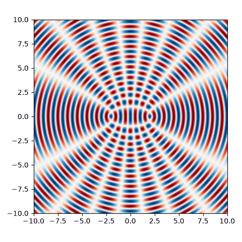

```python
import numpy as np
import matplotlib.pyplot as plt      # plotting is Day 07: enjoy it today

x = np.linspace(-10, 10, 801)
X, Y = np.meshgrid(x, x)             # 801 x 801 grid, no loop
r1 = np.sqrt((X - 2)**2 + Y**2)      # distance to source 1 at (2, 0)
r2 = np.sqrt((X + 2)**2 + Y**2)      # distance to source 2 at (-2, 0)
wave = np.cos(2*np.pi*r1) + np.cos(2*np.pi*r2)   # wavelength 1

plt.imshow(wave, origin='lower', extent=(-10, 10, -10, 10), cmap='RdBu')
plt.show()
```

How `imshow` turns a 2-D array into a picture: Preclass 07 §7.10 (due Mon Oct 5).

### Q. I'm confused about `a>0` vs `np.where(a>0)`

```python
import numpy as np
arr = np.array([[1, 5, 2],
                [4, 0, 6]])
mask = arr < 3   # boolean array, same shape as arr: (2, 3)
```

```python
print("mask =", mask)
print("If we apply the mask to the array:", arr[mask])
```

```python
# One argument: returns a tuple with one index array per axis:
# (row indices, column indices) of the elements where 'arr < 3' is True.
np.where(arr < 3)
```

### `np.where()` with three arguments

`np.where(condition, x, y)` returns an array (not a tuple), same shape as `condition`: `x` where it is `True`, `y` where it is `False`.

```python
arr = np.array([1, 2, 3, 4])
arr2 = np.where(arr<3, # if this condition
                -arr,  # then fill element with this
                arr)   # else fill element with this
arr2
```

### More `np.where()`

```python
print(arr)
```

```python
t0 = np.where(arr<3) # np.where gives indices, similar to masks
print(t0)
```

```python
i1, = np.where(arr<3)   # unpack the one-element tuple: works nicely
print(i1)
```

```python
i2 = np.where(arr<3)[0] # grab the array of indices we care about
print(i2)
```

### Array filtering works with masks and np.where

```python
print( arr[arr<3] )
print( arr[np.where(arr<3)] )
```

### Q. What does `np.where(a2[a2 > 0])` give?

```
import numpy as np
a2 = np.array([-0.15, 0.85, -0.02, 0.24, 0.0, 0.71])
print(a2[a2 > 0])
print(np.where(a2[a2 > 0]))
print(np.where(a2 > 0))
```

**Poll Q1:** `b = np.array([[1, -2], [-3, 4]])`. What does `b[b > 0]` give?

A) `[[1 0] [0 4]]`  
B) `[[ True False] [False True]]`  
C) `[1 4]`  
D) `[[1] [4]]`  
E) `IndexError: Expected integer not boolean for index`

**Poll Q2:** Same array `a = np.array([-2, -1, 0, 1, 2])`. Which line describes the two results correctly?

```
m = a > 0
w = np.where(a > 0)
```

A) both are boolean arrays  
B) `m` is a boolean array, `w` is a tuple holding an index array  
C) `m` is a tuple, `w` is a boolean array  
D) both are index arrays  
E) `m` is a boolean array, `w` is the array `[1 2]`

**Poll Q3:** Which one will produce an error if called with an array as an argument?

```
def f_1(x):                    def f_2(x):
    y = x*x + 1                    y = np.ones(x.size)
    return y                       y[x != 0] = np.sin(x[x != 0])/x[x != 0]
                                   return y

def f_3(x):                    def f_4(x):
    for v in x:                    if (x != 0):
        if v != 0:                     y = np.sin(x)/x
            v = np.sin(v)/v        else:
        else:                          y = 1
            v = 1                  return y
    return x
```

A) `f_1` B) `f_2` C) `f_3` D) `f_4` E) more than one

### Q. The error says "Use `a.any()` or `a.all()`". What are those?

- `m.all()`: `True` only if **every** element of `m` is `True`
- `m.any()`: `True` if **at least one** element is `True`
- `m.all` without `()` is the method itself — Python treats it as true, so `assert m.all` can never fail
- `safe.all(axis=0)` asks the question column by column (Worksheet 06 Task 3d)

```python
import numpy as np
b = np.array([1, 2, 3])
m = b == [1, 2, 9]
print(m)
print(m.any(), m.all())
print(bool(m.all))

safe = np.array([[True, False, True],
                 [True, True,  True]])
print(safe.all(axis=0))
```

**Poll Q4:** After these lines, what is `a`?

```python
import numpy as np
a = np.array([-2, -1, 0, 1, 2])
c = a[1:4]
c[0] = 99
print(a)
```

A) `[-2 -1 0 1 2]` (unchanged)  
B) `[-2 99 0 1 2]`  
C) `[99 -1 0 1 2]`  
D) error

### New today: a slice of an array is a **view**

```python
L = [-2, -1, 0, 1, 2]
s = L[1:4]
s[0] = 99
print(L)
```

- `c = a[1:4]` copies nothing — it is a window onto `a`. Writing through the window writes into `a`
- A list slice `L[1:4]` is a new list: `L` stays `[-2, -1, 0, 1, 2]`

### View or copy? The four cases to know

| you write | you get | writes back into `a`? |
| --- | --- | --- |
| `b = a` | the same object (alias, Day 05) | yes |
| `c = a[1:4]`, `a[:, 0]`, `a.T`, `a.reshape(...)` | a **view** | yes |
| `d = a[a > 0]`, `a[[1, 3]]` | a **copy** (mask / fancy indexing) | no |
| `e = a.copy()`, `a + 0`, `a * 1`, `np.sort(a)` | a new array | no |

If a value changes behind your back — suspect a view. Not sure? `a.copy()` and move on. (This WILL appear on Test 2.)

# The rest of today, and before you leave

- **Group Worksheet 06** (advanced arrays): link on Canvas; one driver per task, swap each task; checkpoint with a TA when done
- **Homework 06** due **Mon Oct 5, 9 am**. **Restart Kernel and Run All Cells before you export**
- **Preclass 07 (plotting with Matplotlib)** due **Mon Oct 5, 9 am**
- **No class Wed Sep 30** (Truth and Reconciliation Day)
- **Test 1**: do one full Practice Test 1 attempt before it